# Untitled

Eric Hirsch

11/14/2021

```r
# Load libraries
library(tidymodels)
library(vip)
library(tidyverse)
library(lmtest)
library(skimr)
library(mltools)
library(psych)
library(data.table)
```

#### 1. Read Data

```r
location = "home"

if (location=="home")
  {
  home_sales <- read.csv("D:\\RStudio\\605_Final\\Final\\housing\\train.csv", stringsAsFactors=TRUE, header = TRUE)
  home_kaggle_test <- read.csv("D:\\RStudio\\605_Final\\Final\\housing\\test.csv", stringsAsFactors=TRUE, header = TRUE)
  } else

  {
  home_sales <- read.csv("C:\\Users\\eric.hirsch\\Desktop\\RStudio\\605_Final\\Final\\housing\\train.csv", stringsAsFactors=TRUE, header = TRUE)
  home_kaggle_test <- read.csv("C:\\Users\\eric.hirsch\\Desktop\\RStudio\\605_Final\\Final\\housing\\test.csv", stringsAsFactors=TRUE, header = TRUE)
  }
```

#### 2. Initial Exploration

```r
dim(home_sales)
```

```
## [1] 1460   81
```

```r
summary(home_sales)
```

```
##        Id           MSSubClass       MSZoning     LotFrontage
##  Min.   :   1.0   Min.   : 20.0   C (all):  10   Min.   : 21.00
##  1st Qu.: 365.8   1st Qu.: 20.0   FV     :  65   1st Qu.: 59.00
##  Median : 730.5   Median : 50.0   RH     :  16   Median : 69.00
##  Mean   : 730.5   Mean   : 56.9   RL     :1151   Mean   : 70.05
##  3rd Qu.:1095.2   3rd Qu.: 70.0   RM     : 218   3rd Qu.: 80.00
##  Max.   :1460.0   Max.   :190.0                  Max.   :313.00
##                                                  NA's   :259
##     LotArea        Street      Alley      LotShape  LandContour  Utilities
##  Min.   :  1300   Grvl:   6   Grvl:  50   IR1:484   Bnk:  63    AllPub:1459
##  1st Qu.:  7554   Pave:1454   Pave:  41   IR2: 41   HLS:  50    NoSeWa:   1
##  Median :  9478               NA's:1369   IR3: 10   Low:  36
##  Mean   : 10517                           Reg:925   Lvl:1311
##  3rd Qu.: 11602
##  Max.   :215245
##
##    LotConfig    LandSlope   Neighborhood   Condition1     Condition2
##  Corner : 263   Gtl:1382   NAmes  :225   Norm   :1260   Norm   :1445
##  CulDSac:  94   Mod:  65   CollgCr:150   Feedr  :  81   Feedr  :   6
##  FR2    :  47   Sev:  13   OldTown:113   Artery :  48   Artery :   2
##  FR3    :   4              Edwards:100   RRAn   :  26   PosN   :   2
##  Inside :1052              Somerst: 86   PosN   :  19   RRNn   :   2
##                            Gilbert: 79   RRAe   :  11   PosA   :   1
##                            (Other):707   (Other):  15   (Other):   2
##    BldgType      HouseStyle   OverallQual      OverallCond      YearBuilt
##  1Fam  :1220   1Story :726   Min.   : 1.000   Min.   :1.000   Min.   :1872
##  2fmCon:  31   2Story :445   1st Qu.: 5.000   1st Qu.:5.000   1st Qu.:1954
##  Duplex:  52   1.5Fin :154   Median : 6.000   Median :5.000   Median :1973
##  Twnhs :  43   SLvl   : 65   Mean   : 6.099   Mean   :5.575   Mean   :1971
##  TwnhsE: 114   SFoyer : 37   3rd Qu.: 7.000   3rd Qu.:6.000   3rd Qu.:2000
##                1.5Unf : 14   Max.   :10.000   Max.   :9.000   Max.   :2010
##                (Other): 19
##   YearRemodAdd    RoofStyle       RoofMatl     Exterior1st   Exterior2nd
##  Min.   :1950   Flat   :  13   CompShg:1434   VinylSd:515   VinylSd:504
##  1st Qu.:1967   Gable  :1141   Tar&Grv:  11   HdBoard:222   MetalSd:214
##  Median :1994   Gambrel:  11   WdShngl:   6   MetalSd:220   HdBoard:207
##  Mean   :1985   Hip    : 286   WdShake:   5   Wd Sdng:206   Wd Sdng:197
##  3rd Qu.:2004   Mansard:   7   ClyTile:   1   Plywood:108   Plywood:142
##  Max.   :2010   Shed   :   2   Membran:   1   CemntBd: 61   CmentBd: 60
##                                (Other):   2   (Other):128   (Other):136
```

[output cut: 81 more lines]

```
##  Min.   :    0.00   Min.   : 1.000   Min.   :2006   WD     :1267
##  1st Qu.:    0.00   1st Qu.: 5.000   1st Qu.:2007   New    : 122
##  Median :    0.00   Median : 6.000   Median :2008   COD    :  43
##  Mean   :   43.49   Mean   : 6.322   Mean   :2008   ConLD  :   9
##  3rd Qu.:    0.00   3rd Qu.: 8.000   3rd Qu.:2009   ConLI  :   5
##  Max.   :15500.00   Max.   :12.000   Max.   :2010   ConLw  :   5
##                                                     (Other):   9
##  SaleCondition    SalePrice
##  Abnorml: 101   Min.   : 34900
##  AdjLand:   4   1st Qu.:129975
##  Alloca :  12   Median :163000
##  Family :  20   Mean   :180921
##  Normal :1198   3rd Qu.:214000
##  Partial: 125   Max.   :755000
##
```

```r
skim(home_sales)
```

Data summary

| Name | home_sales |
| --- | --- |
| Number of rows | 1460 |
| Number of columns | 81 |
| _______________________ |  |
| Column type frequency: |  |
| factor | 43 |
| numeric | 38 |
| ________________________ |  |
| Group variables | None |

**Variable type: factor**

| skim_variable | n_missing | complete_rate | ordered | n_unique | top_counts |
| --- | --- | --- | --- | --- | --- |
| MSZoning | 0 | 1.00 | FALSE | 5 | RL: 1151, RM: 218, FV: 65, RH: 16 |
| Street | 0 | 1.00 | FALSE | 2 | Pav: 1454, Grv: 6 |
| Alley | 1369 | 0.06 | FALSE | 2 | Grv: 50, Pav: 41 |
| LotShape | 0 | 1.00 | FALSE | 4 | Reg: 925, IR1: 484, IR2: 41, IR3: 10 |
| LandContour | 0 | 1.00 | FALSE | 4 | Lvl: 1311, Bnk: 63, HLS: 50, Low: 36 |
| Utilities | 0 | 1.00 | FALSE | 2 | All: 1459, NoS: 1 |
| LotConfig | 0 | 1.00 | FALSE | 5 | Ins: 1052, Cor: 263, Cul: 94, FR2: 47 |
| LandSlope | 0 | 1.00 | FALSE | 3 | Gtl: 1382, Mod: 65, Sev: 13 |
| Neighborhood | 0 | 1.00 | FALSE | 25 | NAm: 225, Col: 150, Old: 113, Edw: 100 |
| Condition1 | 0 | 1.00 | FALSE | 9 | Nor: 1260, Fee: 81, Art: 48, RRA: 26 |
| Condition2 | 0 | 1.00 | FALSE | 8 | Nor: 1445, Fee: 6, Art: 2, Pos: 2 |
| BldgType | 0 | 1.00 | FALSE | 5 | 1Fa: 1220, Twn: 114, Dup: 52, Twn: 43 |
| HouseStyle | 0 | 1.00 | FALSE | 8 | 1St: 726, 2St: 445, 1.5: 154, SLv: 65 |
| RoofStyle | 0 | 1.00 | FALSE | 6 | Gab: 1141, Hip: 286, Fla: 13, Gam: 11 |
| RoofMatl | 0 | 1.00 | FALSE | 8 | Com: 1434, Tar: 11, WdS: 6, WdS: 5 |
| Exterior1st | 0 | 1.00 | FALSE | 15 | Vin: 515, HdB: 222, Met: 220, Wd : 206 |
| Exterior2nd | 0 | 1.00 | FALSE | 16 | Vin: 504, Met: 214, HdB: 207, Wd : 197 |
| MasVnrType | 8 | 0.99 | FALSE | 4 | Non: 864, Brk: 445, Sto: 128, Brk: 15 |
| ExterQual | 0 | 1.00 | FALSE | 4 | TA: 906, Gd: 488, Ex: 52, Fa: 14 |
| ExterCond | 0 | 1.00 | FALSE | 5 | TA: 1282, Gd: 146, Fa: 28, Ex: 3 |
| Foundation | 0 | 1.00 | FALSE | 6 | PCo: 647, CBl: 634, Brk: 146, Sla: 24 |
| BsmtQual | 37 | 0.97 | FALSE | 4 | TA: 649, Gd: 618, Ex: 121, Fa: 35 |
| BsmtCond | 37 | 0.97 | FALSE | 4 | TA: 1311, Gd: 65, Fa: 45, Po: 2 |
| BsmtExposure | 38 | 0.97 | FALSE | 4 | No: 953, Av: 221, Gd: 134, Mn: 114 |
| BsmtFinType1 | 37 | 0.97 | FALSE | 6 | Unf: 430, GLQ: 418, ALQ: 220, BLQ: 148 |
| BsmtFinType2 | 38 | 0.97 | FALSE | 6 | Unf: 1256, Rec: 54, LwQ: 46, BLQ: 33 |
| Heating | 0 | 1.00 | FALSE | 6 | Gas: 1428, Gas: 18, Gra: 7, Wal: 4 |
| HeatingQC | 0 | 1.00 | FALSE | 5 | Ex: 741, TA: 428, Gd: 241, Fa: 49 |
| CentralAir | 0 | 1.00 | FALSE | 2 | Y: 1365, N: 95 |
| Electrical | 1 | 1.00 | FALSE | 5 | SBr: 1334, Fus: 94, Fus: 27, Fus: 3 |
| KitchenQual | 0 | 1.00 | FALSE | 4 | TA: 735, Gd: 586, Ex: 100, Fa: 39 |
| Functional | 0 | 1.00 | FALSE | 7 | Typ: 1360, Min: 34, Min: 31, Mod: 15 |
| FireplaceQu | 690 | 0.53 | FALSE | 5 | Gd: 380, TA: 313, Fa: 33, Ex: 24 |
| GarageType | 81 | 0.94 | FALSE | 6 | Att: 870, Det: 387, Bui: 88, Bas: 19 |
| GarageFinish | 81 | 0.94 | FALSE | 3 | Unf: 605, RFn: 422, Fin: 352 |
| GarageQual | 81 | 0.94 | FALSE | 5 | TA: 1311, Fa: 48, Gd: 14, Ex: 3 |
| GarageCond | 81 | 0.94 | FALSE | 5 | TA: 1326, Fa: 35, Gd: 9, Po: 7 |
| PavedDrive | 0 | 1.00 | FALSE | 3 | Y: 1340, N: 90, P: 30 |
| PoolQC | 1453 | 0.00 | FALSE | 3 | Gd: 3, Ex: 2, Fa: 2 |
| Fence | 1179 | 0.19 | FALSE | 4 | MnP: 157, GdP: 59, GdW: 54, MnW: 11 |
| MiscFeature | 1406 | 0.04 | FALSE | 4 | She: 49, Gar: 2, Oth: 2, Ten: 1 |
| SaleType | 0 | 1.00 | FALSE | 9 | WD: 1267, New: 122, COD: 43, Con: 9 |
| SaleCondition | 0 | 1.00 | FALSE | 6 | Nor: 1198, Par: 125, Abn: 101, Fam: 20 |

**Variable type: numeric**

| skim_variable | n_missing | complete_rate | mean | sd | p0 | p25 | p50 | p75 | p100 | hist |
| --- | --- | --- | --- | --- | --- | --- | --- | --- | --- | --- |
| Id | 0 | 1.00 | 730.50 | 421.61 | 1 | 365.75 | 730.5 | 1095.25 | 1460 | ▇▇▇▇▇ |
| MSSubClass | 0 | 1.00 | 56.90 | 42.30 | 20 | 20.00 | 50.0 | 70.00 | 190 | ▇▅▂▁▁ |
| LotFrontage | 259 | 0.82 | 70.05 | 24.28 | 21 | 59.00 | 69.0 | 80.00 | 313 | ▇▃▁▁▁ |
| LotArea | 0 | 1.00 | 10516.83 | 9981.26 | 1300 | 7553.50 | 9478.5 | 11601.50 | 215245 | ▇▁▁▁▁ |
| OverallQual | 0 | 1.00 | 6.10 | 1.38 | 1 | 5.00 | 6.0 | 7.00 | 10 | ▁▂▇▅▁ |
| OverallCond | 0 | 1.00 | 5.58 | 1.11 | 1 | 5.00 | 5.0 | 6.00 | 9 | ▁▁▇▅▁ |
| YearBuilt | 0 | 1.00 | 1971.27 | 30.20 | 1872 | 1954.00 | 1973.0 | 2000.00 | 2010 | ▁▂▃▆▇ |
| YearRemodAdd | 0 | 1.00 | 1984.87 | 20.65 | 1950 | 1967.00 | 1994.0 | 2004.00 | 2010 | ▅▂▂▃▇ |
| MasVnrArea | 8 | 0.99 | 103.69 | 181.07 | 0 | 0.00 | 0.0 | 166.00 | 1600 | ▇▁▁▁▁ |
| BsmtFinSF1 | 0 | 1.00 | 443.64 | 456.10 | 0 | 0.00 | 383.5 | 712.25 | 5644 | ▇▁▁▁▁ |
| BsmtFinSF2 | 0 | 1.00 | 46.55 | 161.32 | 0 | 0.00 | 0.0 | 0.00 | 1474 | ▇▁▁▁▁ |
| BsmtUnfSF | 0 | 1.00 | 567.24 | 441.87 | 0 | 223.00 | 477.5 | 808.00 | 2336 | ▇▅▂▁▁ |
| TotalBsmtSF | 0 | 1.00 | 1057.43 | 438.71 | 0 | 795.75 | 991.5 | 1298.25 | 6110 | ▇▃▁▁▁ |
| X1stFlrSF | 0 | 1.00 | 1162.63 | 386.59 | 334 | 882.00 | 1087.0 | 1391.25 | 4692 | ▇▅▁▁▁ |
| X2ndFlrSF | 0 | 1.00 | 346.99 | 436.53 | 0 | 0.00 | 0.0 | 728.00 | 2065 | ▇▃▂▁▁ |
| LowQualFinSF | 0 | 1.00 | 5.84 | 48.62 | 0 | 0.00 | 0.0 | 0.00 | 572 | ▇▁▁▁▁ |
| GrLivArea | 0 | 1.00 | 1515.46 | 525.48 | 334 | 1129.50 | 1464.0 | 1776.75 | 5642 | ▇▇▁▁▁ |
| BsmtFullBath | 0 | 1.00 | 0.43 | 0.52 | 0 | 0.00 | 0.0 | 1.00 | 3 | ▇▆▁▁▁ |
| BsmtHalfBath | 0 | 1.00 | 0.06 | 0.24 | 0 | 0.00 | 0.0 | 0.00 | 2 | ▇▁▁▁▁ |
| FullBath | 0 | 1.00 | 1.57 | 0.55 | 0 | 1.00 | 2.0 | 2.00 | 3 | ▁▇▁▇▁ |
| HalfBath | 0 | 1.00 | 0.38 | 0.50 | 0 | 0.00 | 0.0 | 1.00 | 2 | ▇▁▅▁▁ |
| BedroomAbvGr | 0 | 1.00 | 2.87 | 0.82 | 0 | 2.00 | 3.0 | 3.00 | 8 | ▁▇▂▁▁ |
| KitchenAbvGr | 0 | 1.00 | 1.05 | 0.22 | 0 | 1.00 | 1.0 | 1.00 | 3 | ▁▇▁▁▁ |
| TotRmsAbvGrd | 0 | 1.00 | 6.52 | 1.63 | 2 | 5.00 | 6.0 | 7.00 | 14 | ▂▇▇▁▁ |
| Fireplaces | 0 | 1.00 | 0.61 | 0.64 | 0 | 0.00 | 1.0 | 1.00 | 3 | ▇▇▁▁▁ |
| GarageYrBlt | 81 | 0.94 | 1978.51 | 24.69 | 1900 | 1961.00 | 1980.0 | 2002.00 | 2010 | ▁▁▅▅▇ |
| GarageCars | 0 | 1.00 | 1.77 | 0.75 | 0 | 1.00 | 2.0 | 2.00 | 4 | ▁▃▇▂▁ |
| GarageArea | 0 | 1.00 | 472.98 | 213.80 | 0 | 334.50 | 480.0 | 576.00 | 1418 | ▂▇▃▁▁ |
| WoodDeckSF | 0 | 1.00 | 94.24 | 125.34 | 0 | 0.00 | 0.0 | 168.00 | 857 | ▇▂▁▁▁ |
| OpenPorchSF | 0 | 1.00 | 46.66 | 66.26 | 0 | 0.00 | 25.0 | 68.00 | 547 | ▇▁▁▁▁ |
| EnclosedPorch | 0 | 1.00 | 21.95 | 61.12 | 0 | 0.00 | 0.0 | 0.00 | 552 | ▇▁▁▁▁ |
| X3SsnPorch | 0 | 1.00 | 3.41 | 29.32 | 0 | 0.00 | 0.0 | 0.00 | 508 | ▇▁▁▁▁ |
| ScreenPorch | 0 | 1.00 | 15.06 | 55.76 | 0 | 0.00 | 0.0 | 0.00 | 480 | ▇▁▁▁▁ |
| PoolArea | 0 | 1.00 | 2.76 | 40.18 | 0 | 0.00 | 0.0 | 0.00 | 738 | ▇▁▁▁▁ |
| MiscVal | 0 | 1.00 | 43.49 | 496.12 | 0 | 0.00 | 0.0 | 0.00 | 15500 | ▇▁▁▁▁ |
| MoSold | 0 | 1.00 | 6.32 | 2.70 | 1 | 5.00 | 6.0 | 8.00 | 12 | ▃▆▇▃▃ |
| YrSold | 0 | 1.00 | 2007.82 | 1.33 | 2006 | 2007.00 | 2008.0 | 2009.00 | 2010 | ▇▇▇▇▅ |
| SalePrice | 0 | 1.00 | 180921.20 | 79442.50 | 34900 | 129975.00 | 163000.0 | 214000.00 | 755000 | ▇▅▁▁▁ |

```r
str(home_sales)
```

```
## 'data.frame':    1460 obs. of  81 variables:
##  $ Id           : int  1 2 3 4 5 6 7 8 9 10 ...
##  $ MSSubClass   : int  60 20 60 70 60 50 20 60 50 190 ...
##  $ MSZoning     : Factor w/ 5 levels "C (all)","FV",..: 4 4 4 4 4 4 4 4 5 4 ...
##  $ LotFrontage  : int  65 80 68 60 84 85 75 NA 51 50 ...
##  $ LotArea      : int  8450 9600 11250 9550 14260 14115 10084 10382 6120 7420 ...
##  $ Street       : Factor w/ 2 levels "Grvl","Pave": 2 2 2 2 2 2 2 2 2 2 ...
##  $ Alley        : Factor w/ 2 levels "Grvl","Pave": NA NA NA NA NA NA NA NA NA NA ...
##  $ LotShape     : Factor w/ 4 levels "IR1","IR2","IR3",..: 4 4 1 1 1 1 4 1 4 4 ...
##  $ LandContour  : Factor w/ 4 levels "Bnk","HLS","Low",..: 4 4 4 4 4 4 4 4 4 4 ...
##  $ Utilities    : Factor w/ 2 levels "AllPub","NoSeWa": 1 1 1 1 1 1 1 1 1 1 ...
##  $ LotConfig    : Factor w/ 5 levels "Corner","CulDSac",..: 5 3 5 1 3 5 5 1 5 1 ...
##  $ LandSlope    : Factor w/ 3 levels "Gtl","Mod","Sev": 1 1 1 1 1 1 1 1 1 1 ...
##  $ Neighborhood : Factor w/ 25 levels "Blmngtn","Blueste",..: 6 25 6 7 14 12 21 17 18 4 ...
##  $ Condition1   : Factor w/ 9 levels "Artery","Feedr",..: 3 2 3 3 3 3 3 5 1 1 ...
```

[output cut: 67 more lines]

#### 3. Wrangle

1. Get rid of columns that have na

We would normally investigate whether valuable data would be lost with this step - however, we can see from the above that most variables are preserved and in the interests of time will proceed.

```r
home_sales2 <- home_sales %>%
  dplyr::select_if(~ !any(is.na(.)))
```

2. Remove utilities because it only has one value and ID because it is irrelevant

```r
home_sales3 <- home_sales2 %>%
  dplyr::select(-Utilities) %>%
  dplyr::select(-Id)
```

3. Scale the numeric variables.

```r
numeric_data <- home_sales3 %>% select_if(is.numeric)
nonnumeric_data <- home_sales3 %>% select_if(Negate(is.numeric))

df.scaled <- as.data.frame(scale(numeric_data))
df.scaled$SalePrice <- numeric_data$SalePrice
```

4. Eliminate unbalanced character variables and then one-hot

```r
nonnumeric_data2 <- nonnumeric_data %>%
  dplyr::select(ExterQual, Exterior1st, HouseStyle, Neighborhood, LotConfig, LotShape, KitchenQual, HeatingQC, Foundation)

nonnumeric_data3 <- one_hot(as.data.table(nonnumeric_data2), dropCols=TRUE)

home_sales4 <- cbind(nonnumeric_data3, df.scaled)
```

4. Take the log of SalePrice - based on the analysis above, the analysis would benefit from this

```r
home_sales_wrangled <- home_sales4 %>%
  mutate(SalePrice = log(SalePrice))
```

#### Choosing variables for a base model

We don’t want to choose all of the variables as this would inevitably lead to multicollinearity, reduction in adjusted R squared and serious overfitting.

```r
dfCor <- as.data.frame(cor(df.scaled, df.scaled$SalePrice))
dfCor
```

```
##                        V1
## MSSubClass    -0.08428414
## LotArea        0.26384335
## OverallQual    0.79098160
## OverallCond   -0.07785589
## YearBuilt      0.52289733
## YearRemodAdd   0.50710097
## BsmtFinSF1     0.38641981
## BsmtFinSF2    -0.01137812
## BsmtUnfSF      0.21447911
## TotalBsmtSF    0.61358055
## X1stFlrSF      0.60585218
## X2ndFlrSF      0.31933380
## LowQualFinSF  -0.02560613
## GrLivArea      0.70862448
## BsmtFullBath   0.22712223
## BsmtHalfBath  -0.01684415
## FullBath       0.56066376
## HalfBath       0.28410768
## BedroomAbvGr   0.16821315
## KitchenAbvGr  -0.13590737
## TotRmsAbvGrd   0.53372316
## Fireplaces     0.46692884
## GarageCars     0.64040920
## GarageArea     0.62343144
## WoodDeckSF     0.32441344
## OpenPorchSF    0.31585623
## EnclosedPorch -0.12857796
## X3SsnPorch     0.04458367
## ScreenPorch    0.11144657
## PoolArea       0.09240355
## MiscVal       -0.02118958
## MoSold         0.04643225
## YrSold        -0.02892259
## SalePrice      1.00000000
```

Based on this analysis, we’ll start with the following numeric variables and then add some categorical variable. We choose based on correlation and not collinear with other obvious variables (e.g. garage area and garage cars):

```r
mod_1 <- lm(SalePrice ~ LotArea + YearBuilt + YearRemodAdd + TotalBsmtSF + X1stFlrSF + GrLivArea + GarageCars + WoodDeckSF + OpenPorchSF + TotRmsAbvGrd + Fireplaces + FullBath, data = home_sales_wrangled)
summary(mod_1)
```

```
##
## Call:
## lm(formula = SalePrice ~ LotArea + YearBuilt + YearRemodAdd +
##     TotalBsmtSF + X1stFlrSF + GrLivArea + GarageCars + WoodDeckSF +
##     OpenPorchSF + TotRmsAbvGrd + Fireplaces + FullBath, data = home_sales_wrangled)
##
## Residuals:
##      Min       1Q   Median       3Q      Max
## -2.39969 -0.08067  0.00942  0.10116  0.58890
##
## Coefficients:
##                Estimate Std. Error  t value Pr(>|t|)
## (Intercept)   1.202e+01  4.672e-03 2573.872  < 2e-16 ***
## LotArea       1.637e-02  5.044e-03    3.246 0.001197 **
## YearBuilt     8.111e-02  7.014e-03   11.564  < 2e-16 ***
## YearRemodAdd  7.420e-02  6.059e-03   12.247  < 2e-16 ***
## TotalBsmtSF   7.132e-02  8.689e-03    8.208 4.93e-16 ***
## X1stFlrSF    -8.353e-03  9.015e-03   -0.927 0.354333
## GrLivArea     1.316e-01  1.048e-02   12.561  < 2e-16 ***
## GarageCars    7.915e-02  6.281e-03   12.601  < 2e-16 ***
## WoodDeckSF    1.850e-02  4.990e-03    3.708 0.000217 ***
## OpenPorchSF   5.140e-03  5.060e-03    1.016 0.309869
## TotRmsAbvGrd  1.122e-02  8.565e-03    1.310 0.190371
## Fireplaces    5.716e-02  5.509e-03   10.376  < 2e-16 ***
## FullBath      1.956e-05  6.949e-03    0.003 0.997755
## ---
## Signif. codes:  0 '***' 0.001 '**' 0.01 '*' 0.05 '.' 0.1 ' ' 1
##
## Residual standard error: 0.1785 on 1447 degrees of freedom
## Multiple R-squared:  0.802,  Adjusted R-squared:  0.8003
## F-statistic: 488.3 on 12 and 1447 DF,  p-value: < 2.2e-16
```

We do the same analysis with categorical variables.

```r
nonnumeric_data4 <- cbind(nonnumeric_data3, df.scaled$SalePrice)
dfCor <- as.data.frame(cor(nonnumeric_data4, nonnumeric_data4$V2))
dfCor
```

```
##                                V1
## ExterQual_Ex          0.451164330
## ExterQual_Fa         -0.115148855
## ExterQual_Gd          0.452466128
## ExterQual_TA         -0.589043523
## Exterior1st_AsbShng  -0.109125822
## Exterior1st_AsphShn  -0.026676602
## Exterior1st_BrkComm  -0.051264124
## Exterior1st_BrkFace   0.032371391
## Exterior1st_CBlock   -0.025028295
## Exterior1st_CemntBd   0.133491762
## Exterior1st_HdBoard  -0.095147646
## Exterior1st_ImStucc   0.026728559
## Exterior1st_MetalSd  -0.167068043
## Exterior1st_Plywood  -0.017719256
## Exterior1st_Stone     0.036180551
## Exterior1st_Stucco   -0.029802258
## Exterior1st_VinylSd   0.305008802
## Exterior1st_Wd Sdng  -0.158619082
## Exterior1st_WdShing  -0.051317406
## HouseStyle_1.5Fin    -0.163466071
## HouseStyle_1.5Unf    -0.087686406
## HouseStyle_1Story    -0.061811101
## HouseStyle_2.5Fin     0.036525722
## HouseStyle_2.5Unf    -0.025855675
## HouseStyle_2Story     0.242880027
## HouseStyle_SFoyer    -0.093089875
## HouseStyle_SLvl      -0.038645433
## Neighborhood_Blmngtn  0.019065650
## Neighborhood_Blueste -0.020250413
## Neighborhood_BrDale  -0.101302836
## Neighborhood_BrkSide -0.143647867
## Neighborhood_ClearCr  0.055718311
## Neighborhood_CollgCr  0.072625993
## Neighborhood_Crawfor  0.071159603
## Neighborhood_Edwards -0.179948964
## Neighborhood_Gilbert  0.035939622
## Neighborhood_IDOTRR  -0.164055852
## Neighborhood_MeadowV -0.112544155
## Neighborhood_Mitchel -0.057845054
```

[output cut: 23 more lines]

```
## KitchenQual_Fa       -0.157198686
## KitchenQual_Gd        0.321641109
## KitchenQual_TA       -0.519297854
## HeatingQC_Ex          0.434543239
## HeatingQC_Fa         -0.133757533
## HeatingQC_Gd         -0.134722493
## HeatingQC_Po         -0.030962201
## HeatingQC_TA         -0.312677045
## Foundation_BrkTil    -0.204117366
## Foundation_CBlock    -0.343262999
## Foundation_PConc      0.497733753
## Foundation_Slab      -0.119740160
## Foundation_Stone     -0.012102631
## Foundation_Wood       0.002711478
## V2                    1.000000000
```

Our Final model

```r
home_sales_wrangled_Final <- home_sales_wrangled %>%
  dplyr::select(SalePrice, LotArea, YearBuilt, YearRemodAdd, TotalBsmtSF, X1stFlrSF, GrLivArea, GarageCars, WoodDeckSF, OpenPorchSF, TotRmsAbvGrd, Fireplaces, FullBath, -LotConfig_Corner:LotConfig_Inside, LotShape_IR1:LotShape_Reg)
mod_2 <- lm(SalePrice ~ ., data = home_sales_wrangled_Final)
summary(mod_2)
```

```
##
## Call:
## lm(formula = SalePrice ~ ., data = home_sales_wrangled_Final)
##
## Residuals:
##      Min       1Q   Median       3Q      Max
## -1.68788 -0.07067  0.00754  0.08927  0.45266
##
## Coefficients: (6 not defined because of singularities)
##                        Estimate Std. Error t value Pr(>|t|)
## (Intercept)           12.201201   0.060849 200.517  < 2e-16 ***
## LotArea                0.016596   0.005098   3.255 0.001159 **
## YearBuilt              0.052924   0.010535   5.024 5.72e-07 ***
## YearRemodAdd           0.058234   0.005915   9.845  < 2e-16 ***
## TotalBsmtSF            0.062413   0.008179   7.631 4.30e-14 ***
## X1stFlrSF             -0.040420   0.014081  -2.871 0.004159 **
## GrLivArea              0.138632   0.015661   8.852  < 2e-16 ***
## GarageCars             0.060758   0.005830  10.421  < 2e-16 ***
## WoodDeckSF             0.021413   0.004499   4.760 2.14e-06 ***
## OpenPorchSF            0.006232   0.004652   1.340 0.180528
## TotRmsAbvGrd           0.015116   0.007873   1.920 0.055076 .
## Fireplaces             0.042155   0.005206   8.098 1.21e-15 ***
## FullBath              -0.001961   0.006531  -0.300 0.763965
## ExterQual_Ex           0.121933   0.029899   4.078 4.80e-05 ***
## ExterQual_Fa          -0.245671   0.046068  -5.333 1.13e-07 ***
## ExterQual_Gd           0.034928   0.014249   2.451 0.014358 *
## ExterQual_TA                 NA         NA      NA       NA
## Exterior1st_AsbShng   -0.084483   0.047533  -1.777 0.075727 .
## Exterior1st_AsphShn    0.031127   0.161970   0.192 0.847631
## Exterior1st_BrkComm   -0.372751   0.115593  -3.225 0.001290 **
## Exterior1st_BrkFace    0.096450   0.038671   2.494 0.012743 *
## Exterior1st_CBlock     0.269128   0.166447   1.617 0.106127
## Exterior1st_CemntBd    0.054094   0.041078   1.317 0.188106
## Exterior1st_HdBoard    0.003150   0.033765   0.093 0.925689
## Exterior1st_ImStucc    0.062485   0.161799   0.386 0.699415
## Exterior1st_MetalSd    0.011538   0.032943   0.350 0.726206
## Exterior1st_Plywood   -0.005964   0.035672  -0.167 0.867236
## Exterior1st_Stone      0.124093   0.118159   1.050 0.293799
## Exterior1st_Stucco    -0.023784   0.044905  -0.530 0.596439
## Exterior1st_VinylSd    0.013061   0.033191   0.394 0.694001
```

[output cut: 35 more lines]

```
## LotConfig_Corner      -0.001265   0.011091  -0.114 0.909221
## LotConfig_CulDSac      0.042573   0.018674   2.280 0.022770 *
## LotConfig_FR2         -0.050026   0.023992  -2.085 0.037244 *
## LotConfig_FR3         -0.033854   0.078985  -0.429 0.668270
## LotConfig_Inside             NA         NA      NA       NA
## LotShape_IR1           0.003674   0.010167   0.361 0.717905
## LotShape_IR2           0.031639   0.027288   1.159 0.246477
## LotShape_IR3          -0.209407   0.053200  -3.936 8.68e-05 ***
## LotShape_Reg                 NA         NA      NA       NA
## ---
## Signif. codes:  0 '***' 0.001 '**' 0.01 '*' 0.05 '.' 0.1 ' ' 1
##
## Residual standard error: 0.1555 on 1392 degrees of freedom
## Multiple R-squared:  0.8555, Adjusted R-squared:  0.8486
## F-statistic:   123 on 67 and 1392 DF,  p-value: < 2.2e-16
```

We now step through the model to see the effect on adjusted R squared of eliminating variables. We do this with the R Step_AIC function.

```r
library(MASS)
step1 <- stepAIC(mod_2, trace=FALSE)
summary(step1)
```

```
##
## Call:
## lm(formula = SalePrice ~ LotArea + YearBuilt + YearRemodAdd +
##     TotalBsmtSF + X1stFlrSF + GrLivArea + GarageCars + WoodDeckSF +
##     OpenPorchSF + TotRmsAbvGrd + Fireplaces + ExterQual_Ex +
##     ExterQual_Fa + ExterQual_Gd + Exterior1st_AsbShng + Exterior1st_BrkComm +
##     Exterior1st_BrkFace + Exterior1st_CBlock + Exterior1st_CemntBd +
##     HouseStyle_1.5Fin + HouseStyle_1Story + HouseStyle_2Story +
##     Neighborhood_Blmngtn + Neighborhood_Blueste + Neighborhood_BrDale +
##     Neighborhood_BrkSide + Neighborhood_ClearCr + Neighborhood_CollgCr +
##     Neighborhood_Edwards + Neighborhood_Gilbert + Neighborhood_IDOTRR +
##     Neighborhood_MeadowV + Neighborhood_Mitchel + Neighborhood_NAmes +
##     Neighborhood_NPkVill + Neighborhood_NWAmes + Neighborhood_OldTown +
##     Neighborhood_Sawyer + Neighborhood_SawyerW + Neighborhood_Somerst +
##     Neighborhood_StoneBr + Neighborhood_SWISU + Neighborhood_Timber +
##     LotConfig_CulDSac + LotConfig_FR2 + LotShape_IR3, data = home_sales_wrangled_Final)
##
## Residuals:
##      Min       1Q   Median       3Q      Max
## -1.70678 -0.06919  0.00698  0.08967  0.44429
##
## Coefficients:
##                       Estimate Std. Error t value Pr(>|t|)
## (Intercept)          12.210131   0.020784 587.491  < 2e-16 ***
## LotArea               0.017177   0.004950   3.470 0.000536 ***
## YearBuilt             0.055347   0.008780   6.304 3.87e-10 ***
## YearRemodAdd          0.059384   0.005746  10.335  < 2e-16 ***
## TotalBsmtSF           0.060680   0.007801   7.779 1.40e-14 ***
## X1stFlrSF            -0.034522   0.012356  -2.794 0.005277 **
## GrLivArea             0.130573   0.013179   9.908  < 2e-16 ***
## GarageCars            0.060718   0.005740  10.579  < 2e-16 ***
## WoodDeckSF            0.020869   0.004412   4.730 2.47e-06 ***
## OpenPorchSF           0.006721   0.004564   1.473 0.141101
## TotRmsAbvGrd          0.015397   0.007580   2.031 0.042417 *
## Fireplaces            0.041652   0.005057   8.237 3.98e-16 ***
## ExterQual_Ex          0.129186   0.028414   4.547 5.92e-06 ***
## ExterQual_Fa         -0.240883   0.045471  -5.298 1.36e-07 ***
## ExterQual_Gd          0.035159   0.013863   2.536 0.011312 *
## Exterior1st_AsbShng  -0.089004   0.035832  -2.484 0.013110 *
## Exterior1st_BrkComm  -0.378983   0.111112  -3.411 0.000666 ***
```

[output cut: 21 more lines]

```
## Neighborhood_Sawyer  -0.209401   0.024155  -8.669  < 2e-16 ***
## Neighborhood_SawyerW -0.160759   0.024413  -6.585 6.40e-11 ***
## Neighborhood_Somerst -0.076205   0.022551  -3.379 0.000747 ***
## Neighborhood_StoneBr  0.059844   0.034087   1.756 0.079368 .
## Neighborhood_SWISU   -0.191249   0.037018  -5.166 2.73e-07 ***
## Neighborhood_Timber  -0.079425   0.028857  -2.752 0.005993 **
## LotConfig_CulDSac     0.045693   0.017207   2.655 0.008010 **
## LotConfig_FR2        -0.048623   0.023339  -2.083 0.037396 *
## LotShape_IR3         -0.216193   0.052148  -4.146 3.59e-05 ***
## ---
## Signif. codes:  0 '***' 0.001 '**' 0.01 '*' 0.05 '.' 0.1 ' ' 1
##
## Residual standard error: 0.1547 on 1413 degrees of freedom
## Multiple R-squared:  0.8548, Adjusted R-squared:  0.8501
## F-statistic: 180.8 on 46 and 1413 DF,  p-value: < 2.2e-16
```

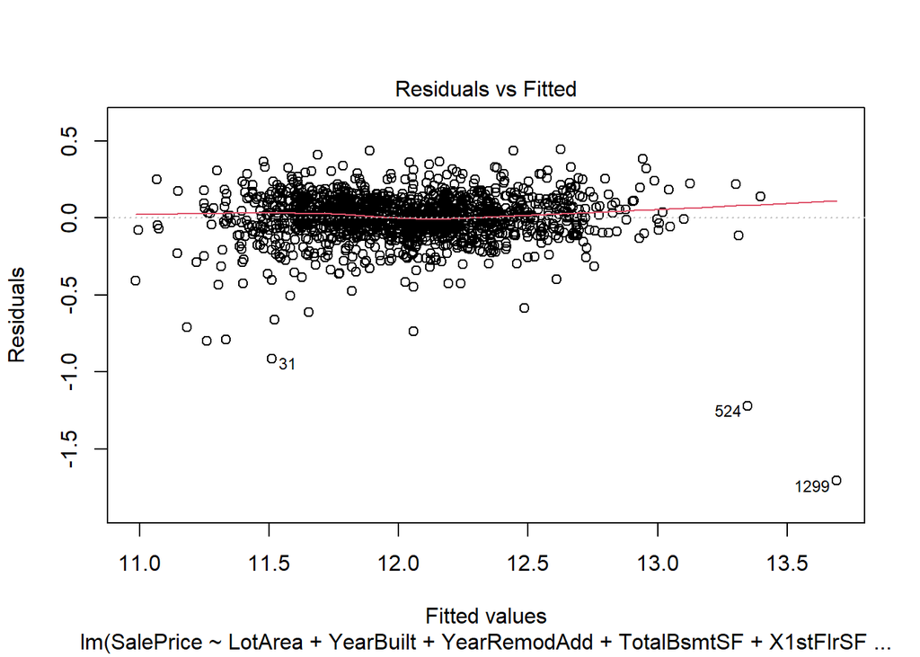

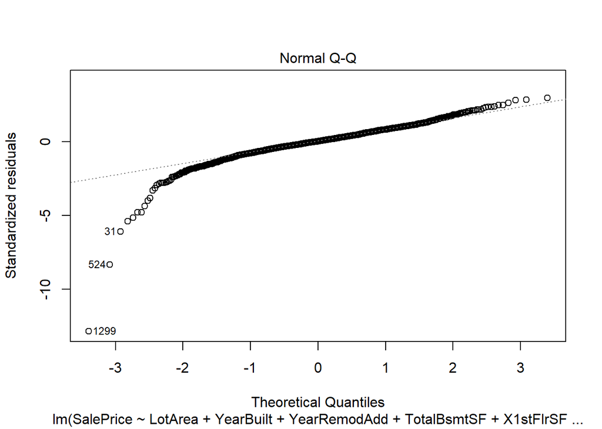

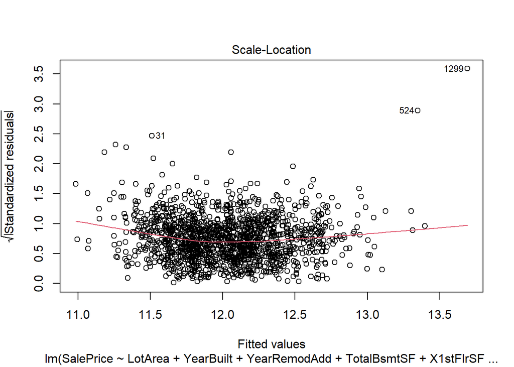

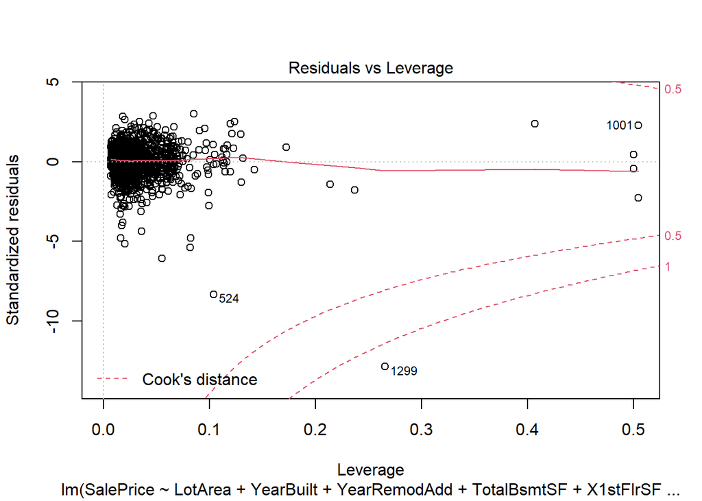

```r
plot(step1)
```

Thus our final df:

```r
dfFinal <- step1$model
head(dfFinal)
```

```
##   SalePrice     LotArea  YearBuilt YearRemodAdd TotalBsmtSF   X1stFlrSF
## 1  12.24769 -0.20707076  1.0506338    0.8783671  -0.4591452 -0.79316202
## 2  12.10901 -0.09185490  0.1566800   -0.4294298   0.4663051  0.25705235
## 3  12.31717  0.07345481  0.9844150    0.8299302  -0.3132614 -0.62761099
## 4  11.84940 -0.09686428 -1.8629933   -0.7200514  -0.6870887 -0.52155486
## 5  12.42922  0.37501979  0.9513056    0.7330564   0.1996113 -0.04559563
## 6  11.87060  0.36049258  0.7195398    0.4908717  -0.5959113 -0.94836612
##    GrLivArea GarageCars WoodDeckSF OpenPorchSF TotRmsAbvGrd Fireplaces
## 1  0.3702066  0.3116179 -0.7519182  0.21642900    0.9118973 -0.9509007
## 2 -0.4823466  0.3116179  1.6256378 -0.70424195   -0.3185741  0.6002892
## 3  0.5148362  0.3116179 -0.7519182 -0.07033736   -0.3185741  0.6002892
## 4  0.3835277  1.6497417 -0.7519182 -0.17598812    0.2966616  0.6002892
## 5  1.2988806  1.6497417  0.7799299  0.56356723    1.5271330  0.6002892
## 6 -0.2920446  0.3116179 -0.4327832 -0.25145296   -0.9338098 -0.9509007
##   ExterQual_Ex ExterQual_Fa ExterQual_Gd Exterior1st_AsbShng
```

[output cut: 76 more lines]

Load test data and prepare as we did the training data

```r
numeric_data_test <- home_kaggle_test %>% select_if(is.numeric)
nonnumeric_data_test <- home_kaggle_test %>% select_if(Negate(is.numeric))

#1. one-hot the categorical variables

nonnumeric_data_test1 <- nonnumeric_data_test %>%
  dplyr::select(ExterQual, Exterior1st, HouseStyle, Neighborhood, KitchenQual, HeatingQC, Foundation)

nonnumeric_data_OneHot <- one_hot(as.data.table(nonnumeric_data_test1), dropCols=TRUE)

#Scale the numeric variables

df.scaled_test <- as.data.frame(scale(numeric_data_test))
df.scaled_test$Id <- numeric_data_test$Id

#recombine

dfTest_Final <- cbind(df.scaled_test, nonnumeric_data_OneHot)
```

#Check if the dataset is missing columns from the test dataset and if so drop them from the original

```r
library(janitor)
compare_df_cols(dfTest_Final, dfFinal)
```

```
##              column_name dfTest_Final dfFinal
## 1           BedroomAbvGr      numeric    <NA>
## 2             BsmtFinSF1      numeric    <NA>
## 3             BsmtFinSF2      numeric    <NA>
## 4           BsmtFullBath      numeric    <NA>
## 5           BsmtHalfBath      numeric    <NA>
## 6              BsmtUnfSF      numeric    <NA>
## 7          EnclosedPorch      numeric    <NA>
## 8    Exterior1st_AsbShng      integer integer
## 9    Exterior1st_AsphShn      integer    <NA>
## 10   Exterior1st_BrkComm      integer integer
## 11   Exterior1st_BrkFace      integer integer
## 12    Exterior1st_CBlock      integer integer
## 13   Exterior1st_CemntBd      integer integer
## 14   Exterior1st_HdBoard      integer    <NA>
```

[output cut: 91 more lines]

```r
dfFinal1 <- dfFinal %>%
  dplyr::select(-LotConfig_CulDSac) %>%
  dplyr::select(-LotConfig_FR2)  %>%
  dplyr::select(-LotShape_IR3)
```

Run the model

```r
mod_3 <- lm(SalePrice ~ ., data = dfFinal1)
summary(mod_3)
```

```
##
## Call:
## lm(formula = SalePrice ~ ., data = dfFinal1)
##
## Residuals:
##      Min       1Q   Median       3Q      Max
## -1.88190 -0.06774  0.00570  0.09016  0.45200
##
## Coefficients:
##                       Estimate Std. Error t value Pr(>|t|)
## (Intercept)          12.213769   0.020797 587.292  < 2e-16 ***
## LotArea               0.013571   0.004791   2.832 0.004685 **
## YearBuilt             0.054391   0.008852   6.144 1.04e-09 ***
## YearRemodAdd          0.059118   0.005795  10.201  < 2e-16 ***
## TotalBsmtSF           0.057700   0.007840   7.360 3.12e-13 ***
## X1stFlrSF            -0.031653   0.012455  -2.541 0.011146 *
## GrLivArea             0.128515   0.013291   9.669  < 2e-16 ***
## GarageCars            0.061541   0.005788  10.632  < 2e-16 ***
## WoodDeckSF            0.021887   0.004446   4.923 9.55e-07 ***
## OpenPorchSF           0.006798   0.004600   1.478 0.139674
## TotRmsAbvGrd          0.015724   0.007640   2.058 0.039764 *
## Fireplaces            0.042165   0.005099   8.269 3.07e-16 ***
## ExterQual_Ex          0.128777   0.028674   4.491 7.66e-06 ***
## ExterQual_Fa         -0.239340   0.045886  -5.216 2.10e-07 ***
## ExterQual_Gd          0.035292   0.013989   2.523 0.011751 *
## Exterior1st_AsbShng  -0.088973   0.036159  -2.461 0.013988 *
## Exterior1st_BrkComm  -0.379176   0.112127  -3.382 0.000740 ***
## Exterior1st_BrkFace   0.091316   0.023630   3.864 0.000116 ***
## Exterior1st_CBlock    0.257909   0.163828   1.574 0.115649
## Exterior1st_CemntBd   0.042395   0.025970   1.632 0.102806
## HouseStyle_1.5Fin    -0.037863   0.020529  -1.844 0.065346 .
## HouseStyle_1Story    -0.043242   0.016514  -2.618 0.008927 **
## HouseStyle_2Story    -0.077341   0.021290  -3.633 0.000290 ***
## Neighborhood_Blmngtn -0.214474   0.041020  -5.229 1.96e-07 ***
## Neighborhood_Blueste -0.297890   0.112023  -2.659 0.007921 **
## Neighborhood_BrDale  -0.339369   0.044015  -7.710 2.35e-14 ***
## Neighborhood_BrkSide -0.181601   0.028458  -6.381 2.37e-10 ***
## Neighborhood_ClearCr -0.092684   0.033935  -2.731 0.006388 **
## Neighborhood_CollgCr -0.122900   0.019169  -6.411 1.96e-10 ***
## Neighborhood_Edwards -0.264518   0.022806 -11.599  < 2e-16 ***
## Neighborhood_Gilbert -0.177160   0.023252  -7.619 4.65e-14 ***
## Neighborhood_IDOTRR  -0.337085   0.033582 -10.038  < 2e-16 ***
## Neighborhood_MeadowV -0.480354   0.050200  -9.569  < 2e-16 ***
## Neighborhood_Mitchel -0.205311   0.027384  -7.497 1.14e-13 ***
## Neighborhood_NAmes   -0.166444   0.018917  -8.798  < 2e-16 ***
## Neighborhood_NPkVill -0.214338   0.054710  -3.918 9.37e-05 ***
## Neighborhood_NWAmes  -0.150322   0.023255  -6.464 1.40e-10 ***
## Neighborhood_OldTown -0.267340   0.025049 -10.673  < 2e-16 ***
## Neighborhood_Sawyer  -0.208357   0.024308  -8.572  < 2e-16 ***
## Neighborhood_SawyerW -0.163728   0.024521  -6.677 3.49e-11 ***
## Neighborhood_Somerst -0.077411   0.022738  -3.405 0.000681 ***
## Neighborhood_StoneBr  0.070917   0.034226   2.072 0.038441 *
## Neighborhood_SWISU   -0.195840   0.037291  -5.252 1.74e-07 ***
## Neighborhood_Timber  -0.078573   0.029061  -2.704 0.006939 **
## ---
## Signif. codes:  0 '***' 0.001 '**' 0.01 '*' 0.05 '.' 0.1 ' ' 1
##
## Residual standard error: 0.1561 on 1416 degrees of freedom
## Multiple R-squared:  0.8518, Adjusted R-squared:  0.8473
## F-statistic: 189.3 on 43 and 1416 DF,  p-value: < 2.2e-16
```

```r
step2 <- stepAIC(mod_3, trace=FALSE)
summary(step2)
```

```
##
## Call:
## lm(formula = SalePrice ~ LotArea + YearBuilt + YearRemodAdd +
##     TotalBsmtSF + X1stFlrSF + GrLivArea + GarageCars + WoodDeckSF +
##     OpenPorchSF + TotRmsAbvGrd + Fireplaces + ExterQual_Ex +
##     ExterQual_Fa + ExterQual_Gd + Exterior1st_AsbShng + Exterior1st_BrkComm +
##     Exterior1st_BrkFace + Exterior1st_CBlock + Exterior1st_CemntBd +
##     HouseStyle_1.5Fin + HouseStyle_1Story + HouseStyle_2Story +
##     Neighborhood_Blmngtn + Neighborhood_Blueste + Neighborhood_BrDale +
##     Neighborhood_BrkSide + Neighborhood_ClearCr + Neighborhood_CollgCr +
##     Neighborhood_Edwards + Neighborhood_Gilbert + Neighborhood_IDOTRR +
##     Neighborhood_MeadowV + Neighborhood_Mitchel + Neighborhood_NAmes +
##     Neighborhood_NPkVill + Neighborhood_NWAmes + Neighborhood_OldTown +
##     Neighborhood_Sawyer + Neighborhood_SawyerW + Neighborhood_Somerst +
##     Neighborhood_StoneBr + Neighborhood_SWISU + Neighborhood_Timber,
##     data = dfFinal1)
##
## Residuals:
##      Min       1Q   Median       3Q      Max
## -1.88190 -0.06774  0.00570  0.09016  0.45200
##
## Coefficients:
##                       Estimate Std. Error t value Pr(>|t|)
## (Intercept)          12.213769   0.020797 587.292  < 2e-16 ***
## LotArea               0.013571   0.004791   2.832 0.004685 **
## YearBuilt             0.054391   0.008852   6.144 1.04e-09 ***
## YearRemodAdd          0.059118   0.005795  10.201  < 2e-16 ***
## TotalBsmtSF           0.057700   0.007840   7.360 3.12e-13 ***
## X1stFlrSF            -0.031653   0.012455  -2.541 0.011146 *
## GrLivArea             0.128515   0.013291   9.669  < 2e-16 ***
## GarageCars            0.061541   0.005788  10.632  < 2e-16 ***
## WoodDeckSF            0.021887   0.004446   4.923 9.55e-07 ***
## OpenPorchSF           0.006798   0.004600   1.478 0.139674
## TotRmsAbvGrd          0.015724   0.007640   2.058 0.039764 *
## Fireplaces            0.042165   0.005099   8.269 3.07e-16 ***
## ExterQual_Ex          0.128777   0.028674   4.491 7.66e-06 ***
## ExterQual_Fa         -0.239340   0.045886  -5.216 2.10e-07 ***
## ExterQual_Gd          0.035292   0.013989   2.523 0.011751 *
## Exterior1st_AsbShng  -0.088973   0.036159  -2.461 0.013988 *
## Exterior1st_BrkComm  -0.379176   0.112127  -3.382 0.000740 ***
```

[output cut: 18 more lines]

```
## Neighborhood_NPkVill -0.214338   0.054710  -3.918 9.37e-05 ***
## Neighborhood_NWAmes  -0.150322   0.023255  -6.464 1.40e-10 ***
## Neighborhood_OldTown -0.267340   0.025049 -10.673  < 2e-16 ***
## Neighborhood_Sawyer  -0.208357   0.024308  -8.572  < 2e-16 ***
## Neighborhood_SawyerW -0.163728   0.024521  -6.677 3.49e-11 ***
## Neighborhood_Somerst -0.077411   0.022738  -3.405 0.000681 ***
## Neighborhood_StoneBr  0.070917   0.034226   2.072 0.038441 *
## Neighborhood_SWISU   -0.195840   0.037291  -5.252 1.74e-07 ***
## Neighborhood_Timber  -0.078573   0.029061  -2.704 0.006939 **
## ---
## Signif. codes:  0 '***' 0.001 '**' 0.01 '*' 0.05 '.' 0.1 ' ' 1
##
## Residual standard error: 0.1561 on 1416 degrees of freedom
## Multiple R-squared:  0.8518, Adjusted R-squared:  0.8473
## F-statistic: 189.3 on 43 and 1416 DF,  p-value: < 2.2e-16
```

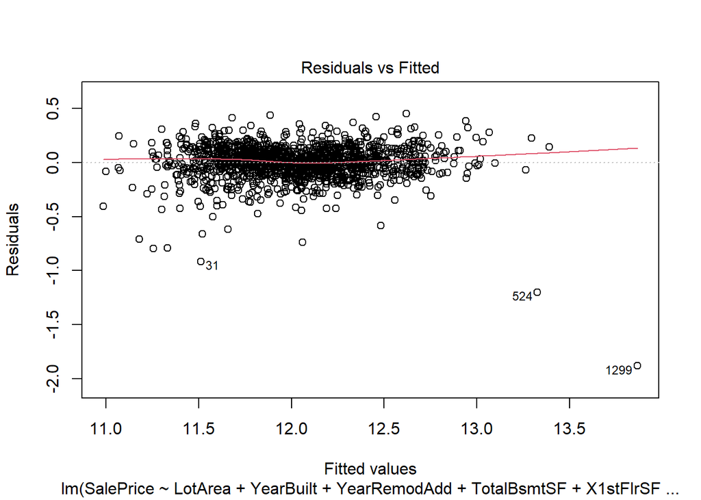

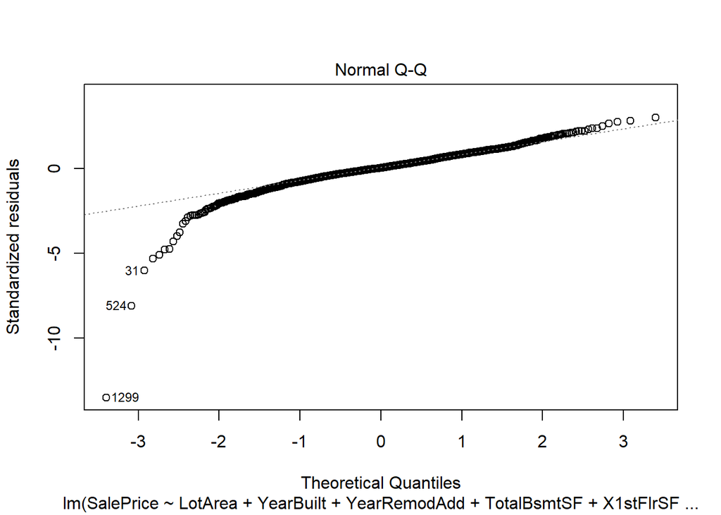

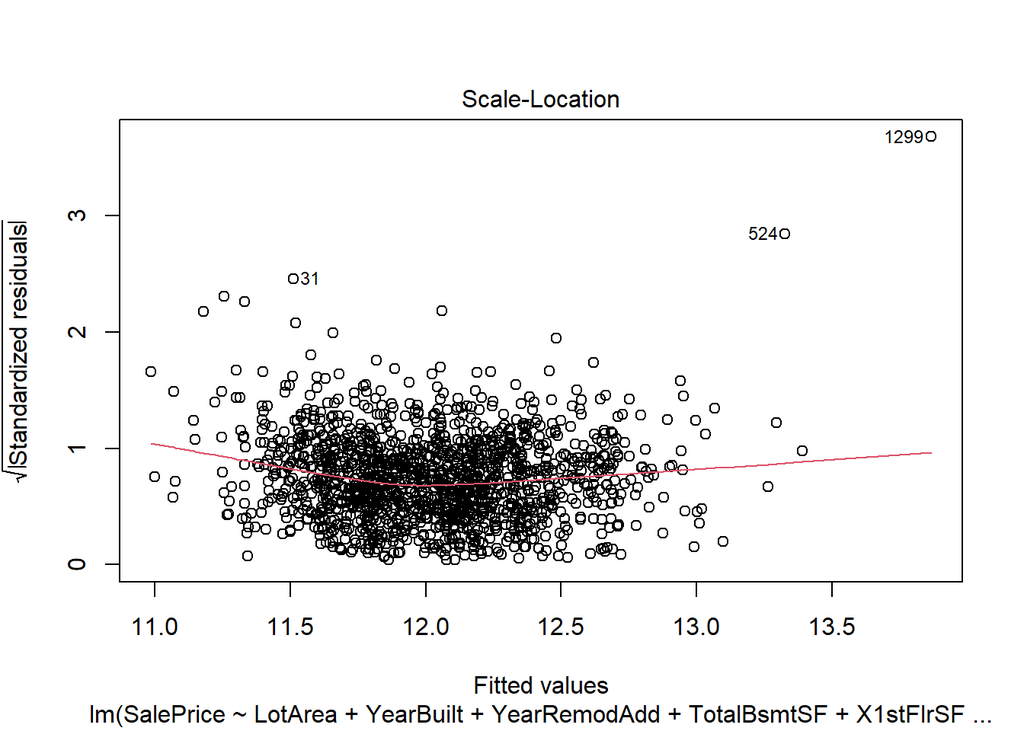

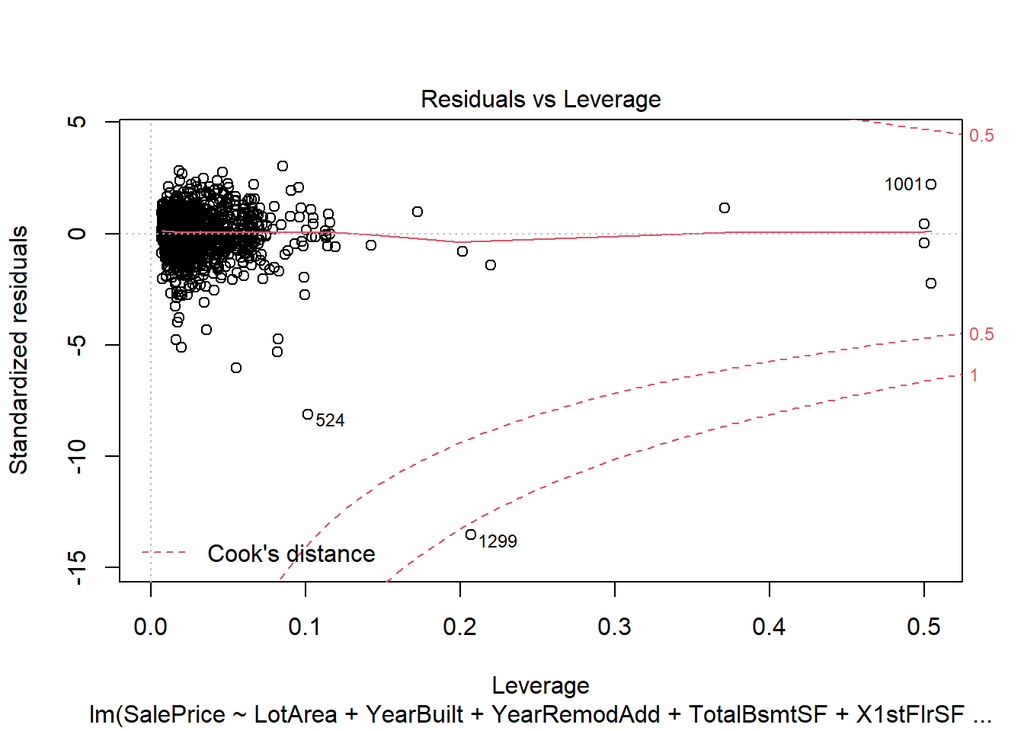

```r
plot(step2)
```

Remove outliers

```r
dfFinal2 <- slice(dfFinal1, -1299)
dfFinal2 <- slice(dfFinal2, -524)
dfFinal2 <- slice(dfFinal2, -1001)
dfFinal2 <- slice(dfFinal2, -31)
```

```r
mod_4 <- lm(SalePrice ~ ., data = dfFinal2)
summary(mod_4)
```

```
##
## Call:
## lm(formula = SalePrice ~ ., data = dfFinal2)
##
## Residuals:
##      Min       1Q   Median       3Q      Max
## -0.85245 -0.06368  0.00562  0.08197  0.47766
##
## Coefficients:
##                       Estimate Std. Error t value Pr(>|t|)
## (Intercept)          12.184517   0.018419 661.520  < 2e-16 ***
## LotArea               0.020612   0.004246   4.854 1.34e-06 ***
## YearBuilt             0.058128   0.007819   7.434 1.82e-13 ***
## YearRemodAdd          0.057846   0.005122  11.294  < 2e-16 ***
## TotalBsmtSF           0.085189   0.007098  12.001  < 2e-16 ***
## X1stFlrSF            -0.018010   0.011022  -1.634 0.102475
## GrLivArea             0.152960   0.011833  12.927  < 2e-16 ***
## GarageCars            0.051109   0.005145   9.934  < 2e-16 ***
## WoodDeckSF            0.018174   0.003931   4.623 4.12e-06 ***
## OpenPorchSF           0.010199   0.004074   2.503 0.012417 *
## TotRmsAbvGrd         -0.009063   0.006871  -1.319 0.187370
## Fireplaces            0.036658   0.004516   8.118 1.02e-15 ***
## ExterQual_Ex          0.162524   0.025376   6.405 2.05e-10 ***
## ExterQual_Fa         -0.239455   0.040545  -5.906 4.39e-09 ***
## ExterQual_Gd          0.022691   0.012368   1.835 0.066768 .
## Exterior1st_AsbShng  -0.091811   0.031926  -2.876 0.004091 **
## Exterior1st_BrkComm  -0.407107   0.098998  -4.112 4.14e-05 ***
## Exterior1st_BrkFace   0.102229   0.021088   4.848 1.39e-06 ***
## Exterior1st_CBlock    0.258496   0.144636   1.787 0.074117 .
## Exterior1st_CemntBd   0.045762   0.023118   1.979 0.047954 *
## HouseStyle_1.5Fin    -0.046657   0.018135  -2.573 0.010189 *
## HouseStyle_1Story    -0.064764   0.014632  -4.426 1.03e-05 ***
## HouseStyle_2Story    -0.048383   0.018859  -2.566 0.010404 *
## Neighborhood_Blmngtn -0.158479   0.036321  -4.363 1.37e-05 ***
## Neighborhood_Blueste -0.246990   0.098928  -2.497 0.012650 *
## Neighborhood_BrDale  -0.290807   0.038955  -7.465 1.45e-13 ***
## Neighborhood_BrkSide -0.120275   0.025318  -4.751 2.24e-06 ***
## Neighborhood_ClearCr -0.089036   0.029958  -2.972 0.003009 **
## Neighborhood_CollgCr -0.088941   0.017012  -5.228 1.97e-07 ***
## Neighborhood_Edwards -0.178329   0.020631  -8.644  < 2e-16 ***
## Neighborhood_Gilbert -0.134458   0.020648  -6.512 1.03e-10 ***
## Neighborhood_IDOTRR  -0.246790   0.030107  -8.197 5.47e-16 ***
## Neighborhood_MeadowV -0.435541   0.044472  -9.794  < 2e-16 ***
## Neighborhood_Mitchel -0.166922   0.024254  -6.882 8.82e-12 ***
## Neighborhood_NAmes   -0.123121   0.016864  -7.301 4.75e-13 ***
## Neighborhood_NPkVill -0.166768   0.048363  -3.448 0.000581 ***
## Neighborhood_NWAmes  -0.127403   0.020565  -6.195 7.62e-10 ***
## Neighborhood_OldTown -0.214608   0.022315  -9.617  < 2e-16 ***
## Neighborhood_Sawyer  -0.156012   0.021628  -7.213 8.88e-13 ***
## Neighborhood_SawyerW -0.128743   0.021721  -5.927 3.87e-09 ***
## Neighborhood_Somerst -0.054814   0.020118  -2.725 0.006517 **
## Neighborhood_StoneBr  0.068261   0.030222   2.259 0.024059 *
## Neighborhood_SWISU   -0.154230   0.032987  -4.675 3.21e-06 ***
## Neighborhood_Timber  -0.066128   0.025662  -2.577 0.010071 *
## ---
## Signif. codes:  0 '***' 0.001 '**' 0.01 '*' 0.05 '.' 0.1 ' ' 1
##
## Residual standard error: 0.1378 on 1412 degrees of freedom
## Multiple R-squared:  0.8836, Adjusted R-squared:  0.8801
## F-statistic: 249.3 on 43 and 1412 DF,  p-value: < 2.2e-16
```

```r
step3 <- stepAIC(mod_4, trace=FALSE)
summary(step3)
```

```
##
## Call:
## lm(formula = SalePrice ~ LotArea + YearBuilt + YearRemodAdd +
##     TotalBsmtSF + X1stFlrSF + GrLivArea + GarageCars + WoodDeckSF +
##     OpenPorchSF + Fireplaces + ExterQual_Ex + ExterQual_Fa +
##     ExterQual_Gd + Exterior1st_AsbShng + Exterior1st_BrkComm +
##     Exterior1st_BrkFace + Exterior1st_CBlock + Exterior1st_CemntBd +
##     HouseStyle_1.5Fin + HouseStyle_1Story + HouseStyle_2Story +
##     Neighborhood_Blmngtn + Neighborhood_Blueste + Neighborhood_BrDale +
##     Neighborhood_BrkSide + Neighborhood_ClearCr + Neighborhood_CollgCr +
##     Neighborhood_Edwards + Neighborhood_Gilbert + Neighborhood_IDOTRR +
##     Neighborhood_MeadowV + Neighborhood_Mitchel + Neighborhood_NAmes +
##     Neighborhood_NPkVill + Neighborhood_NWAmes + Neighborhood_OldTown +
##     Neighborhood_Sawyer + Neighborhood_SawyerW + Neighborhood_Somerst +
##     Neighborhood_StoneBr + Neighborhood_SWISU + Neighborhood_Timber,
##     data = dfFinal2)
##
## Residuals:
##      Min       1Q   Median       3Q      Max
## -0.84991 -0.06463  0.00657  0.08277  0.46858
##
## Coefficients:
##                       Estimate Std. Error t value Pr(>|t|)
## (Intercept)          12.185204   0.018416 661.649  < 2e-16 ***
## LotArea               0.020709   0.004247   4.876 1.20e-06 ***
## YearBuilt             0.058808   0.007804   7.535 8.66e-14 ***
## YearRemodAdd          0.057914   0.005123  11.305  < 2e-16 ***
## TotalBsmtSF           0.085668   0.007091  12.081  < 2e-16 ***
## X1stFlrSF            -0.018528   0.011018  -1.682 0.092862 .
## GrLivArea             0.145016   0.010188  14.234  < 2e-16 ***
## GarageCars            0.050918   0.005144   9.898  < 2e-16 ***
## WoodDeckSF            0.018384   0.003929   4.680 3.15e-06 ***
## OpenPorchSF           0.010318   0.004074   2.532 0.011434 *
## Fireplaces            0.037274   0.004492   8.297 2.46e-16 ***
## ExterQual_Ex          0.160405   0.025332   6.332 3.24e-10 ***
## ExterQual_Fa         -0.239260   0.040556  -5.900 4.56e-09 ***
## ExterQual_Gd          0.023677   0.012349   1.917 0.055390 .
## Exterior1st_AsbShng  -0.092328   0.031932  -2.891 0.003893 **
## Exterior1st_BrkComm  -0.400186   0.098884  -4.047 5.47e-05 ***
## Exterior1st_BrkFace   0.103476   0.021072   4.911 1.01e-06 ***
```

[output cut: 17 more lines]

```
## Neighborhood_NPkVill -0.167077   0.048375  -3.454 0.000569 ***
## Neighborhood_NWAmes  -0.129147   0.020528  -6.291 4.19e-10 ***
## Neighborhood_OldTown -0.214474   0.022320  -9.609  < 2e-16 ***
## Neighborhood_Sawyer  -0.157900   0.021587  -7.315 4.31e-13 ***
## Neighborhood_SawyerW -0.129637   0.021716  -5.970 3.00e-09 ***
## Neighborhood_Somerst -0.054504   0.020122  -2.709 0.006836 **
## Neighborhood_StoneBr  0.069965   0.030203   2.317 0.020672 *
## Neighborhood_SWISU   -0.154650   0.032994  -4.687 3.04e-06 ***
## Neighborhood_Timber  -0.068075   0.025626  -2.656 0.007986 **
## ---
## Signif. codes:  0 '***' 0.001 '**' 0.01 '*' 0.05 '.' 0.1 ' ' 1
##
## Residual standard error: 0.1378 on 1413 degrees of freedom
## Multiple R-squared:  0.8835, Adjusted R-squared:   0.88
## F-statistic:   255 on 42 and 1413 DF,  p-value: < 2.2e-16
```

Transform GrLivArea

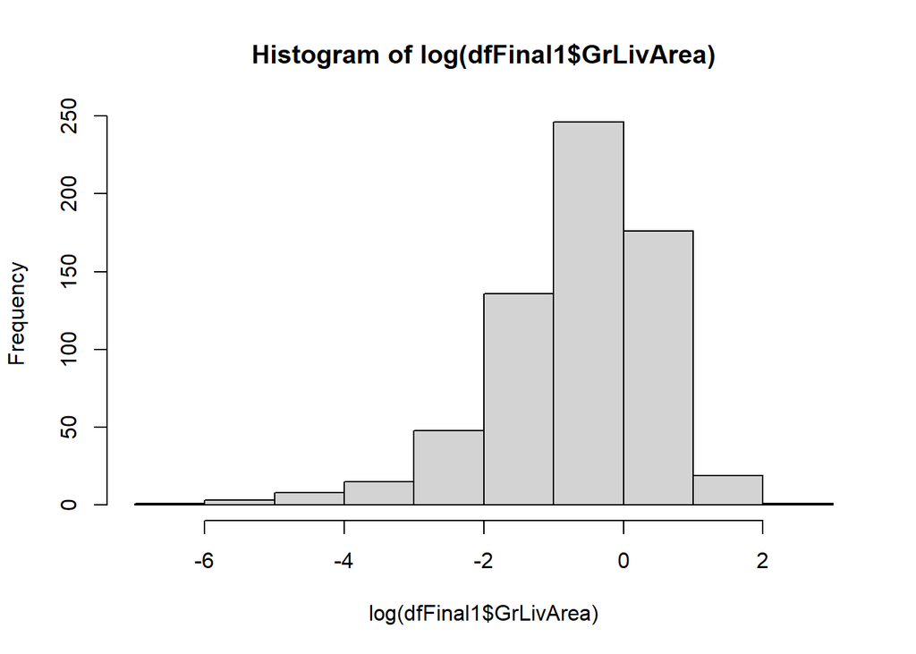

```r
hist(log(dfFinal1$GrLivArea))
```

```r
dfFinal3 <- dfFinal1 %>%
  mutate(GrLivArea = log(GrLivArea+10))

mod_5 <- lm(SalePrice ~ ., data = dfFinal3)
summary(mod_5)
```

```
##
## Call:
## lm(formula = SalePrice ~ ., data = dfFinal3)
##
## Residuals:
##      Min       1Q   Median       3Q      Max
## -1.66173 -0.06803  0.00794  0.08677  0.43754
##
## Coefficients:
##                        Estimate Std. Error t value Pr(>|t|)
## (Intercept)           7.9145252  0.3358443  23.566  < 2e-16 ***
## LotArea               0.0146196  0.0046822   3.122 0.001830 **
## YearBuilt             0.0556259  0.0086491   6.431 1.72e-10 ***
## YearRemodAdd          0.0580192  0.0056670  10.238  < 2e-16 ***
## TotalBsmtSF           0.0618662  0.0076737   8.062 1.58e-15 ***
## X1stFlrSF            -0.0612698  0.0125510  -4.882 1.17e-06 ***
## GrLivArea             1.8747263  0.1465816  12.790  < 2e-16 ***
## GarageCars            0.0586787  0.0056689  10.351  < 2e-16 ***
## WoodDeckSF            0.0212264  0.0043464   4.884 1.16e-06 ***
## OpenPorchSF           0.0049501  0.0044982   1.100 0.271320
## TotRmsAbvGrd         -0.0003815  0.0076837  -0.050 0.960405
## Fireplaces            0.0391882  0.0049981   7.841 8.76e-15 ***
## ExterQual_Ex          0.1388800  0.0280339   4.954 8.14e-07 ***
## ExterQual_Fa         -0.2434183  0.0447849  -5.435 6.43e-08 ***
## ExterQual_Gd          0.0277706  0.0137025   2.027 0.042883 *
## Exterior1st_AsbShng  -0.0910350  0.0353482  -2.575 0.010114 *
## Exterior1st_BrkComm  -0.3945603  0.1096245  -3.599 0.000330 ***
## Exterior1st_BrkFace   0.0884352  0.0231028   3.828 0.000135 ***
## Exterior1st_CBlock    0.2554167  0.1601275   1.595 0.110917
## Exterior1st_CemntBd   0.0421593  0.0253872   1.661 0.097005 .
## HouseStyle_1.5Fin    -0.0703287  0.0204629  -3.437 0.000605 ***
## HouseStyle_1Story    -0.0303095  0.0161142  -1.881 0.060188 .
## HouseStyle_2Story    -0.1230973  0.0214174  -5.748 1.11e-08 ***
## Neighborhood_Blmngtn -0.2062551  0.0401060  -5.143 3.09e-07 ***
## Neighborhood_Blueste -0.2985775  0.1095096  -2.726 0.006480 **
## Neighborhood_BrDale  -0.3168104  0.0431121  -7.349 3.37e-13 ***
## Neighborhood_BrkSide -0.1681261  0.0278684  -6.033 2.05e-09 ***
## Neighborhood_ClearCr -0.1002057  0.0331834  -3.020 0.002575 **
## Neighborhood_CollgCr -0.1188165  0.0187448  -6.339 3.11e-10 ***
## Neighborhood_Edwards -0.2536144  0.0223293 -11.358  < 2e-16 ***
## Neighborhood_Gilbert -0.1757117  0.0227239  -7.732 1.99e-14 ***
## Neighborhood_IDOTRR  -0.3217160  0.0328830  -9.784  < 2e-16 ***
## Neighborhood_MeadowV -0.4614038  0.0491209  -9.393  < 2e-16 ***
## Neighborhood_Mitchel -0.1992582  0.0267801  -7.441 1.73e-13 ***
## Neighborhood_NAmes   -0.1604592  0.0185075  -8.670  < 2e-16 ***
## Neighborhood_NPkVill -0.2017497  0.0535039  -3.771 0.000169 ***
## Neighborhood_NWAmes  -0.1507122  0.0227240  -6.632 4.69e-11 ***
## Neighborhood_OldTown -0.2637837  0.0244884 -10.772  < 2e-16 ***
## Neighborhood_Sawyer  -0.1996414  0.0237871  -8.393  < 2e-16 ***
## Neighborhood_SawyerW -0.1587257  0.0239777  -6.620 5.09e-11 ***
## Neighborhood_Somerst -0.0758650  0.0222151  -3.415 0.000656 ***
## Neighborhood_StoneBr  0.0667364  0.0334618   1.994 0.046299 *
## Neighborhood_SWISU   -0.2026206  0.0364531  -5.558 3.25e-08 ***
## Neighborhood_Timber  -0.0780967  0.0283910  -2.751 0.006022 **
## ---
## Signif. codes:  0 '***' 0.001 '**' 0.01 '*' 0.05 '.' 0.1 ' ' 1
##
## Residual standard error: 0.1526 on 1416 degrees of freedom
## Multiple R-squared:  0.8584, Adjusted R-squared:  0.8541
## F-statistic: 199.6 on 43 and 1416 DF,  p-value: < 2.2e-16
```

```r
step4 <- stepAIC(mod_5, trace=FALSE)
summary(step4)
```

```
##
## Call:
## lm(formula = SalePrice ~ LotArea + YearBuilt + YearRemodAdd +
##     TotalBsmtSF + X1stFlrSF + GrLivArea + GarageCars + WoodDeckSF +
##     Fireplaces + ExterQual_Ex + ExterQual_Fa + ExterQual_Gd +
##     Exterior1st_AsbShng + Exterior1st_BrkComm + Exterior1st_BrkFace +
##     Exterior1st_CBlock + Exterior1st_CemntBd + HouseStyle_1.5Fin +
##     HouseStyle_1Story + HouseStyle_2Story + Neighborhood_Blmngtn +
##     Neighborhood_Blueste + Neighborhood_BrDale + Neighborhood_BrkSide +
##     Neighborhood_ClearCr + Neighborhood_CollgCr + Neighborhood_Edwards +
##     Neighborhood_Gilbert + Neighborhood_IDOTRR + Neighborhood_MeadowV +
##     Neighborhood_Mitchel + Neighborhood_NAmes + Neighborhood_NPkVill +
##     Neighborhood_NWAmes + Neighborhood_OldTown + Neighborhood_Sawyer +
##     Neighborhood_SawyerW + Neighborhood_Somerst + Neighborhood_StoneBr +
##     Neighborhood_SWISU + Neighborhood_Timber, data = dfFinal3)
##
## Residuals:
##      Min       1Q   Median       3Q      Max
## -1.65915 -0.06941  0.00617  0.08781  0.43457
##
## Coefficients:
##                       Estimate Std. Error t value Pr(>|t|)
## (Intercept)           7.881012   0.279819  28.165  < 2e-16 ***
## LotArea               0.014730   0.004679   3.148 0.001677 **
## YearBuilt             0.056125   0.008615   6.515 1.01e-10 ***
## YearRemodAdd          0.058246   0.005661  10.288  < 2e-16 ***
## TotalBsmtSF           0.062645   0.007625   8.216 4.70e-16 ***
## X1stFlrSF            -0.062105   0.012516  -4.962 7.82e-07 ***
## GrLivArea             1.888663   0.122358  15.436  < 2e-16 ***
## GarageCars            0.058487   0.005662  10.329  < 2e-16 ***
## WoodDeckSF            0.021011   0.004338   4.843 1.42e-06 ***
## Fireplaces            0.039509   0.004960   7.966 3.35e-15 ***
## ExterQual_Ex          0.141563   0.027853   5.083 4.22e-07 ***
## ExterQual_Fa         -0.245314   0.044739  -5.483 4.94e-08 ***
## ExterQual_Gd          0.028686   0.013647   2.102 0.035730 *
## Exterior1st_AsbShng  -0.092394   0.035316  -2.616 0.008985 **
## Exterior1st_BrkComm  -0.395712   0.109433  -3.616 0.000310 ***
## Exterior1st_BrkFace   0.087790   0.023064   3.806 0.000147 ***
## Exterior1st_CBlock    0.255222   0.160077   1.594 0.111075
## Exterior1st_CemntBd   0.042651   0.025353   1.682 0.092734 .
```

[output cut: 15 more lines]

```
## Neighborhood_NPkVill -0.199879   0.053462  -3.739 0.000192 ***
## Neighborhood_NWAmes  -0.148614   0.022606  -6.574 6.86e-11 ***
## Neighborhood_OldTown -0.260346   0.024280 -10.723  < 2e-16 ***
## Neighborhood_Sawyer  -0.198588   0.023724  -8.371  < 2e-16 ***
## Neighborhood_SawyerW -0.157300   0.023929  -6.573 6.89e-11 ***
## Neighborhood_Somerst -0.072092   0.021942  -3.286 0.001043 **
## Neighborhood_StoneBr  0.065838   0.033408   1.971 0.048952 *
## Neighborhood_SWISU   -0.200336   0.036384  -5.506 4.35e-08 ***
## Neighborhood_Timber  -0.078032   0.028348  -2.753 0.005988 **
## ---
## Signif. codes:  0 '***' 0.001 '**' 0.01 '*' 0.05 '.' 0.1 ' ' 1
##
## Residual standard error: 0.1525 on 1418 degrees of freedom
## Multiple R-squared:  0.8583, Adjusted R-squared:  0.8542
## F-statistic: 209.4 on 41 and 1418 DF,  p-value: < 2.2e-16
```

Predict the model

```r
predictions <- predict(step2,newdata=dfTest_Final)
predictions <- data.frame(as.vector(predictions))
predictions$Id <- dfTest_Final$Id
predictions[,c(1,2)] <- predictions[,c(2,1)]
colnames(predictions) <- c("Id", "SalePrice")
predictions[is.na(predictions)] <- log(mean(home_sales$SalePrice))
predictions$SalePrice <- exp(predictions$SalePrice)
head(predictions)
```

```
##     Id SalePrice
## 1 1461  115895.6
## 2 1462  140037.0
## 3 1463  190542.2
## 4 1464  194488.3
## 5 1465  207640.5
## 6 1466  185948.4
```

```r
#write_csv(predictions, "C:\\Users\\eric.hirsch\\Desktop\\people8.csv")
```

Removing outliers is not an improvement (.17020) Neither is using the mean (.16984) So we stick with step2, the original model. Transforming GrLivArea also hurts the model (.23417) Best model is step 2.